# CSE 280A Assignment 2

#### 02/04/2024

### Question 1

```python
import os
import re
import numpy as np
import matplotlib.pyplot as plt
import pandas as pd
from tqdm import tqdm
from scipy.stats.distributions import chi2
import skimage
```

```python
with open('txt_files/pop2.txt') as infile:
    pop2 = infile.read()
```

```python
msms_params = re.search('(?=ms).*?(?=\\\n)', pop2).group(0)
segsites = eval(re.search('(?<=segsites: ).*?(?=\\\n)', pop2).group(0))
positions = list(map(eval, (re.search('(?<=positions: ).*?(?=\\\n)', pop2).group(0).strip().split(' '))))
haplotypes = list(map(eval, (re.search('(?<=\\\n).*?(?<=\\\n)', pop2).groups())))
snp_matrix = np.array([list(map(int, x)) for x in re.findall('(?<=\\\n)[0-1]*?(?=\\\n)', pop2) if x]).astype(bool)
```

```python
column_1_index = 100
column_2_index = 200
```

```python
D_prime_matrix = np.zeros((snp_matrix.shape[1], snp_matrix.shape[1]))
for column_1_index in tqdm(range(snp_matrix.shape[1])):
    for column_2_index in range(snp_matrix.shape[1]):
        column_1 = snp_matrix[:,column_1_index]
        column_2 = snp_matrix[:,column_2_index]

        p00 = (~column_1 * ~column_2).sum() / snp_matrix.shape[0]
        p0s_x_ps0 = ((~column_1).sum()*(~column_2).sum()) / np.square(snp_matrix.shape[0])
        D = p00 - p0s_x_ps0
        if D > 0:
            D_max = min((~column_1).sum()*(column_2).sum(), (column_1).sum()*(~column_2).sum())
        else:
            D_max = min((~column_1).sum()*(~column_2).sum(), (column_1).sum()*(column_2).sum())
        D_max /= np.square(snp_matrix.shape[0])
        D_prime = np.abs(D) / D_max
        D_prime_matrix[column_1_index, column_2_index] = D_prime
```

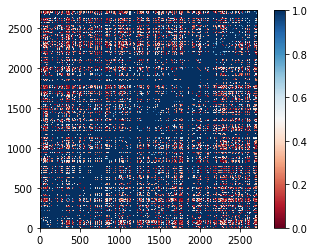

```python
fig, ax = plt.subplots()
# ax.tick_params(top=True, bottom=False, labelbottom=False)
plt.imshow(D_prime_matrix, interpolation='None', cmap='RdBu', origin='lower')
plt.savefig("fig_1.jpg")
img = skimage.io.imread("fig_1.jpg")
plt.colorbar()
# ax.set_yticks(range(0, snp_matrix.shape[1], 500))
```

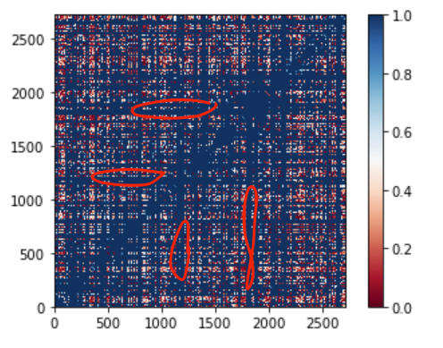

Examples of Haplotype blocks are circled in red

```python
df = 3
nlogp_matrix = []
for column_1_index in tqdm(range(snp_matrix.shape[1])):
    nlogp_matrix.append([])
    for column_2_index in range(snp_matrix.shape[1]):
        column_1 = snp_matrix[:,column_1_index]
        column_2 = snp_matrix[:,column_2_index]

        p00 = (~column_1 * ~column_2).sum() / snp_matrix.shape[0]
        p0s_x_ps0 = ((~column_1).sum()*(~column_2).sum()) / np.square(snp_matrix.shape[0])
        D = p00 - p0s_x_ps0


        p1s = column_1.sum()
        ps1 = column_2.sum()
        denom = np.sqrt(p1s * (snp_matrix.shape[0]-p1s) * ps1 * (snp_matrix.shape[0]-ps1))
        denom /= np.square(snp_matrix.shape[0])
        r = np.abs(D) / denom
        chi2_value = np.square(r) * snp_matrix.shape[0]
        nlog_pvalue = -chi2.logsf(chi2_value, df)
        nlogp_matrix[-1].append(nlog_pvalue)
nlogp_matrix = np.array(nlogp_matrix)
```

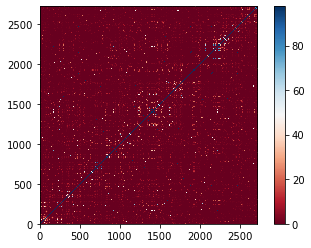

```python
fig, ax = plt.subplots()
# ax.tick_params(top=True, bottom=False, labelbottom=False)
plt.imshow(nlogp_matrix, interpolation='None', cmap='RdBu', origin='lower')
plt.colorbar()
# ax.set_yticks(range(0, snp_matrix.shape[1], 500))
```

### Question 2

If the two sites were in perfect linkage equilibrium, the probability of seeing the haplotype '11' would be (0.01 * 0.01 = 0.0001).

Therefore even if the gene was on an autosome, we have only sampled 20 haplotypes, the expected value in this case assuming HWE is $20 \times 0.0001 = 0.002$. The expected number of individuals which do $\it{not}$ have haplotype '11' is $20\times0.9999 = 19.998$. Using a chi squared test, with one degree of freedom...

```python
chi2.sf((np.square(-0.002) / 0.002) + (np.square(20 - 19.998) / np.square(19.998)), 1)
```

```
0.9643293191355615
```

The probability of seeing this event assuming Linkage Equilibrium is 96.4% which is not surprising at all. Therefore we cannot reject the null hypothesis that the sites are in linkage equilibrium.

```python
chi2.sf((np.square(-2000) / 2000) + (np.square(1000000 - 998000) / 998000), 1)
```

```
0.0
```

The probability of this event is extremely unlikely, therefore we can reject the null hypothesis that the sites are in linkage equilibrium. Thus we would have evidence that the sites are in LD.

The power of the experiment to assess the LD status of 2 sites increases as the expected number of individuals with both minor alleles increases. If the minor allele frequency is too small, then the expected number of individuals who have both minor alleles assuming HWE will be extremely small, thus decreasing the likelihood of seeing an individual with both minor alleles.

### Question 3

a.)

0 does not correspond to the ancestral mutation. 0 indicates the major allele globally, wheras 1 indicates the minor global allele. The 1000 genomes Phase 3 data is phased, as alleles from the two haplotypes are seperated by a vertical bar instead of a forward slash (0|1 instead of 0/1).

b.)

The header to the vcf is on the 253rd line

```python
vcf_path = '/Users/ginoprasad/_School/CSE_280A/homework/homework_2/vcf_files/ALL.chr22.phase3_shapeit2_mvncall_integrated_v5a.20130502.genotypes.vcf'
with open(vcf_path) as infile:
    for _ in range(252):
        infile.readline()
    header = infile.readline().strip().split('\t')
```

```python
header[:9]
```

```
['#CHROM', 'POS', 'ID', 'REF', 'ALT', 'QUAL', 'FILTER', 'INFO', 'FORMAT']
```

The first 9 columns are information about the position of the variant, and other information like the reference, and alternative allele.

```python
print('\t'.join(header[9:][:50]))
```

```
HG00096	HG00097	HG00099	HG00100	HG00101	HG00102	HG00103	HG00105	HG00106	HG00107	HG00108	HG00109	HG00110	HG00111	HG00112	HG00113	HG00114	HG00115	HG00116	HG00117	HG00118	HG00119	HG00120	HG00121	HG00122	HG00123	HG00125	HG00126	HG00127	HG00128	HG00129	HG00130	HG00131	HG00132	HG00133	HG00136	HG00137	HG00…
```

The remaining columns represent the individuals, each of whom has 2 haplotypes

```python
len(header[9:])
```

```
2504
```

##### There are $2504 \times 2 = 5008$ haplotypes

### c.

```python
import subprocess as sp
```

```python
sp.run(f"wc -l {vcf_path}", shell=True, capture_output=True).stdout.decode()
```

```
' 1103800 /Users/ginoprasad/_School/CSE_280A/homework/homework_2/vcf_files/ALL.chr22.phase3_shapeit2_mvncall_integrated_v5a.20130502.genotypes.vcf\n'
```

There are 1103800 lines in the vcf file, and 253 are the header and assembly information.

Therefore there are 1103547 sites total in Chromosome 22.

The first SNP is recorded at position 16050075, and the last SNP in the file is recorded at position 51244237, so $\frac{1103547}{51244237 - 16050075}\times 1000 \approx 31.36 $ per 1000bp

### d.

The number of sites per 1000bp seems extremely high. From the lecture 1 notes, there is around 1 mutation per 1000 bp in humans. However, the 31.36bp figure is more than 30 times higher, which is surprising.

This dataset has 5008, so mutations which are either at almost 1 or almost 0 likely account for a significant number of the segregation sites.

So while a single haplotype from an individual may have 1 mutation per 1000 bp, the number mutation sites in 5008 haplotypes is higher than 1 site per 1000 bp.

### e.

```python
individuals = header[9:]
```

```python
import pandas as pd
samples_df = pd.read_csv("tsv_files/igsr_samples.tsv", sep='\t')
```

YRI only, CEU/CEPH only, and YRI and CEU/CEPH individuals together

```python
vcf_filtered_path = '/Users/ginoprasad/_School/CSE_280A/homework/homework_2/vcf_files/ALL.chr22.phase3_shapeit2_mvncall_integrated_v5a.20130502.genotypes_filtered.vcf'
```

```python
from tqdm import tqdm
import numpy as np
import matplotlib.pyplot as plt
```

```python
filtering_af_threshold = 0.1
positions = []
allele_frequencies = []
with open(vcf_filtered_path, 'w') as outfile:
    with open(vcf_path) as infile:
        for _ in range(252):
            infile.readline()
        infile.readline()
        for line in tqdm(infile):
            af = eval(re.search('(?<=;AF\\=).*?(?=[;,\\,])', line).group(0))

            if af > filtering_af_threshold:
                line = line.split('\t')
                position = int(line[1])
                positions.append(position)
                allele_frequencies.append(af)
                outfile.write(('|'.join(line[9:])).replace('|', ','))
positions = np.array(positions)
allele_frequencies = np.array(allele_frequencies)
```

```
1103547it [00:18, 58503.26it/s]
```

```python
snp_matrix = np.loadtxt(vcf_filtered_path, delimiter=',').astype(bool)
snp_matrix
```

```
array([[False, False,  True, ...,  True, False, False],
       [False,  True, False, ..., False, False, False],
       [False,  True, False, ..., False,  True,  True],
       ...,
       [False, False, False, ...,  True,  True, False],
       [False,  True,  True, ..., False, False, False],
       [False, False, False, ..., False, False, False]])
```

```python
yri_individuals = list(samples_df[samples_df['Population code'] == 'YRI']['Sample name'])
yri_individuals_indices = np.array([individuals.index(x) for x in individuals if x in yri_individuals])
yri_individuals_indices_matrix = np.concatenate([2 * yri_individuals_indices, (2 * yri_individuals_indices)+1])
yri_mask = np.array([i in yri_individuals_indices_matrix for i, x in enumerate(range(snp_matrix.shape[1]))])

ceu_individuals = list(samples_df[samples_df['Population code'] == 'CEU']['Sample name'])
ceu_individuals_indices = np.array([individuals.index(x) for x in individuals if x in ceu_individuals])
ceu_individuals_indices_matrix = np.concatenate([2 * ceu_individuals_indices, (2 * ceu_individuals_indices)+1])
ceu_mask = np.array([i in ceu_individuals_indices_matrix for i, x in enumerate(range(snp_matrix.shape[1]))])

yri_and_ceu_individuals_indices_matrix = np.concatenate([yri_individuals_indices_matrix, ceu_individuals_indices_matrix])
yri_and_ceu_mask = np.array([i in yri_and_ceu_individuals_indices_matrix for i, x in enumerate(range(snp_matrix.shape[1]))])
```

```python
def get_random_snp_pair_x_away(snp_matrix, mask, x):
    while True:
        start_index = np.random.randint(snp_matrix.shape[0])
        start_position = positions[start_index]
        if not snp_matrix[start_index][mask].sum() or not (~snp_matrix[start_index][mask]).sum():
            continue

        low = start_index+1
        high = snp_matrix.shape[0]

        while low < high:
            mid = (low + high) // 2
            mid_distance = (positions[mid] - start_position) / 1000
            if np.round(mid_distance, 2) == np.round(x, 2):
                if not snp_matrix[mid][mask].sum() or not (~snp_matrix[mid][mask]).sum():
                    break
                return snp_matrix[start_index][mask], snp_matrix[mid][mask]
            elif mid_distance < x:
                low = mid + 1
            else:
                high = mid
```

```python
def get_mean_d_prime(snp_matrix, mask, x, n=100):
    statistics = []
    for _ in range(n):
        col1, col2 = get_random_snp_pair_x_away(snp_matrix, mask, x)
        p00 = ((~col1) * (~col2)).sum() / mask.sum()
        p0s = (~col1).sum() / mask.sum()
        ps0 = (~col2).sum() / mask.sum()

        D = p00 - (p0s * ps0)
        if D > 0:
            D_max = min((~col1).sum()*(col2).sum(), (col1).sum()*(~col2).sum())
        else:
            D_max = min((~col1).sum()*(~col2).sum(), (col1).sum()*(col2).sum())
        D_max /= np.square(mask.sum())
        D_prime = np.abs(D) / D_max
        statistics.append(D_prime)
    return np.mean(statistics)
```

```python
x_values = np.linspace(1, 200, 20)
yri_data = np.array([get_mean_d_prime(snp_matrix, yri_mask, x) for x in x_values])
ceu_data = np.array([get_mean_d_prime(snp_matrix, ceu_mask, x) for x in x_values])
yri_and_ceu_data = np.array([get_mean_d_prime(snp_matrix, yri_and_ceu_mask, x) for x in x_values])
```

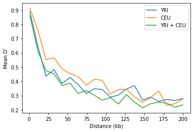

```python
plt.plot(x_values, yri_data, label='YRI')
plt.plot(x_values, ceu_data, label='CEU')
plt.plot(x_values, yri_and_ceu_data, label='YRI + CEU')
plt.ylabel("Mean D'")
plt.xlabel("Distance (kb)")
plt.legend()
```

Yes, these results are consistent with my expectations. I expected the CEU subpopulation to have higher LD between pairs on average compared to the YRI population on average which is what is observed.

### Question 4

For any lineage in $T_k$, it is guaranteed to have at least 1 descendent at $T_n$

Therefore there are (n-k) "free descendents" which can be assigned to any particular lineage, with any configuration of these free descendents being equally likely.

Therefore, for a random lineage to have i descendents, it must have i-1 "free descendents"

So first, we must calculate the number of ways these free descendents can be assigned to all lineage such that a particular lineage has i-1 descendents.

To do this, first subtract the i-1 free descendents from n-k.

Now there are n-k-i+1 free descendents to spread amongst the other k-1 lineages

Therefore there are C(n-k-i+1+k-2, k-2)=C(n-i-1, k-2) ways to do this

To calculate the total number of configurations, we just have to spread the n-k "free descendents" across k lineages.

Therefore there are C(n-k+k-1, k-1) = C(n-1, k-1) total configurations.

So $p_{ki} = \frac{C(n-i-1, k-2)}{C(n-1, k-1)}$

$= \frac{(n-i-1)!}{(k-2)!(n-i-k+1)!}\frac{(k-1)!(n-k)!}{(n-1)!}$

$= \frac{(n-i-1)!}{(n-i-k+1)!}\frac{(n-k)!}{(n-1)!}\frac{(k-1)!}{(k-2)!}$

$= \frac{(n-i-1)!}{(n-i-k+1)!}\frac{(n-k)!}{(n-1)!}(k-1)$

Since $i! = (i-1)!i$

$= \frac{i!}{(i-1)!i}\frac{(n-i-1)!}{(n-i-k+1)!}\frac{(n-k)!}{(n-1)!}(k-1)$

$= \frac{i!}{(i-1)!i}\frac{(n-i-1)!}{(n-i-k+1)!}\frac{(n-k)!}{(n-1)!}(k-1)$

$= \frac{(n-k)!}{(n-i-k+1)!(i-1)!}\frac{(n-i-1)!i!}{(n-1)!}\frac{k-1}{i}$

$= \frac{C(n-k, i-1)}{C(n-1, i)}\frac{k-1}{i}$

The number of mutations with exactly i ones is

$m_i = \sum_{k=2}^n \sum_{j=1}^k x_{j,k} y_{i, j, k}$

where $x_{j, k}$ represents the number of mutations that fall on the jth lineage in epoch $T_k$

And $y_{i,j,k}$ is an indicator variable that is 1 when the jth lineage has i descendents in epoch $T_k$

By linearity of expectation

$E[m_i] = \sum_{k=2}^n \sum_{j=1}^k E[x_{j,k} y_{i, j, k}]$

$E[m_i] = \sum_{k=2}^n k E[x_{j,k} y_{i, j, k}]$

Since $x_{j,k}$ is independent to $y_{i, j, k}$

$E[m_i] = \sum_{k=2}^n k E[x_{j,k}]E[y_{i, j, k}]$

$ = \sum_{k=2}^n k \frac{C(n-k, i-1)}{C(n-1, i)}\frac{k-1}{i} E[x_{j,k}]$

$ = \sum_{k=2}^n k \frac{C(n-k, i-1)}{C(n-1, i)}\frac{k-1}{i} \frac{2N}{C(k, 2)}$

$ = \frac{1}{i}\sum_{k=2}^n \frac{C(n-k, i-1)}{C(n-1, i)}\frac{2}{1}\frac{(k-1)k}{ 2} \frac{2N}{C(k, 2)}$

$ = \frac{1}{i}\sum_{k=2}^n \frac{C(n-k, i-1)}{C(n-1, i)}\frac{2}{1}\frac{(k-1)k}{ 2} \frac{2N}{C(k, 2)}$

$ = \frac{1}{i}\sum_{k=2}^n \frac{C(n-k, i-1)}{C(n-1, i)}\frac{2}{1}\frac{C(k, 2)}{1} \frac{2N \mu l}{C(k, 2)}$

$ = \frac{4N \mu l}{i C(n-1, i)}\sum_{k=2}^n C(n-k, i-1)$

$ = \frac{4N \mu l}{i C(n-1, i)}\sum_{k=2}^n C(n-k, n-k-i+1)$

$ = \frac{4N \mu l}{i C(n-1, i)}[C(0, 0-i+1) + C(1, 1-i+1) + ... + C(n-2, n-i-1)]$

$i \geq 1$ because each lineage must have at least 1 descendent since we are simulating backwards

Since $-i \lt 0$, $C(0, 0-i) = 0$

$ = \frac{4N \mu l}{i C(n-1, i)}[C(0, 0-i) + C(0, 0-i+1) + C(1, 1-i+1) + ... + C(n-2, n-i-1)]$

Since $C(n, r) + C(n, r+1) = C(n+1, r+1)$

$ = \frac{4N \mu l}{i C(n-1, i)}[C(1, 0-i+1) + C(1, 1-i+1) + C(2, 2-i+1) + ... + C(n-2, n-i-1)]$

Repeating this simplification ...

$ = \frac{4N \mu l}{i C(n-1, i)}[C(n-2, n-1-i-1) + C(n-2, n-i-1)]$

$ = \frac{4N \mu l}{i C(n-1, i)}[C(n-1, n-i-1)]$

$ = \frac{4N \mu l}{i} \frac{C(n-1, i)}{C(n-1, i)}$

$ = \frac{4N \mu l}{i}$

$$ E[m_i] =\frac{\theta}{i} $$